# K-Means Clustering: Home Regions

Kim Pham

10/27/2017

## 0. Load libraries

```r
library(dplyr)
library(tidyr)
library(ggplot2)
```

## 1. Upload data file

Data file description: This file contains survey answers to the questions and regions where people grew up.

Code Book:

Duration (in seconds) Q1 - First Name  
Q2 - Last Name  
Q3 - Have you ever owned a cat?  
Q4 - Do you pronounce “gif”, with a J (j-iff) or a G (g-iff)?  
Q5 - How many months have you lived in New York City?  
Q6 - How many siblings (brothers/sisters) do you have?  
Q7 - How many times do you play sport each week?  
Q8 - How many miles do you travel from home to TC?  
Q9 - Estimate how many of your friends own Android phones  
Q10 - How many movies have you seen in the cinema this year?  
Q11 - How many classes are you taking this semester?  
Q12 - How many states have you visited in the US?  
Q13 - What city/town did you grow up in?  
Q14 - What state/province did you grow up in?  
Q15 - What country did you grow up in?

```r
df <- read.csv("Data/HUDK4050_2017_Cluster_Survey.csv")
```

## 2. Process and structure data for kmeans

```r
df <- select(df, -first, -last, -city.grew, -state.grew)
df_answers <- select(df, -country.grew, -cat, -gif.jiff) # remove text columns
#df_answers$cat <- as.integer(df_answers$cat) # convert to integer
#df_answers$gif.jiff <- as.integer(df_answers$gif.jiff) # convert to integer
df_answers[!complete.cases(df_answers),] # no NAs exist
```

```
## [1] live.nyc    sibling     play.sport  travel.dist android     movies
## [7] classes     states
## <0 rows> (or 0-length row.names)
```

```r
df_s <- scale(df_answers) # scale data
head(df_s)
```

```
##        live.nyc     sibling play.sport travel.dist    android     movies
## [1,] -0.2404162  0.07709911  0.5342935  -0.6705146 -0.2969633 -0.2727317
## [2,] -0.5846243 -0.88663974 -1.5747597  -0.6662132 -0.3350356 -0.7841036
## [3,] -0.5846243 -0.88663974  0.5342935  -0.6490076 -0.2017828  0.5795548
## [4,]  0.2626573 -0.88663974 -0.1687243  -0.6705146 -0.2969633  0.5795548
## [5,] -0.3463264 -0.88663974  1.2373112  -0.6692242 -0.2017828 -0.6136463
## [6,] -0.1874611 -0.88663974 -0.8717420   1.6952642 -0.2017828 -0.1022744
##         classes     states
## [1,] -0.4141421 -0.5703415
## [2,]  1.3114499 -0.3704554
## [3,]  1.3114499 -0.7702275
## [4,] -1.2769380 -0.5037128
## [5,] -0.4141421 -0.4370841
## [6,] -0.4141421 -0.2371981
```

```r
summary(df_s)
```

```
##     live.nyc          sibling          play.sport       travel.dist
##  Min.   :-0.6376   Min.   :-0.8866   Min.   :-1.5748   Min.   :-0.7781
##  1st Qu.:-0.5581   1st Qu.:-0.8866   1st Qu.:-0.8717   1st Qu.:-0.6673
##  Median :-0.2669   Median : 0.0771   Median :-0.1687   Median :-0.5630
##  Mean   : 0.0000   Mean   : 0.0000   Mean   : 0.0000   Mean   : 0.0000
##  3rd Qu.: 0.2627   3rd Qu.: 1.0408   3rd Qu.: 0.5343   3rd Qu.: 0.5124
##  Max.   : 4.3932   Max.   : 2.9683   Max.   : 1.2373   Max.   : 2.1254
##     android            movies           classes            states
##  Min.   :-0.3921   Min.   :-1.1250   Min.   :-2.1397   Min.   :-0.77023
##  1st Qu.:-0.3350   1st Qu.:-0.6136   1st Qu.:-0.4141   1st Qu.:-0.63697
##  Median :-0.2970   Median :-0.2727   Median :-0.4141   Median :-0.37046
##  Mean   : 0.0000   Mean   : 0.0000   Mean   : 0.0000   Mean   : 0.00000
##  3rd Qu.:-0.2018   3rd Qu.: 0.5796   3rd Qu.: 0.4487   3rd Qu.:-0.03731
##  Max.   : 4.3669   Max.   : 2.2841   Max.   : 1.3114   Max.   : 2.42795
```

## 3. Run K-means using 2 clusters

```r
fit <- kmeans(df_s, 2, nstart=50, iter.max=15)
df_cluster <- data.frame(df, fit$cluster)
head(df_cluster)
```

```
##   cat gif.jiff live.nyc sibling play.sport travel.dist android movies
## 1 Yes    g-iff       15       1          3       0.000       5      5
## 2  No    g-iff        2       0          0       0.020       3      2
## 3  No    j-iff        2       0          3       0.100      10     10
## 4  No    g-iff       34       0          2       0.000       5     10
## 5  No    g-iff       11       0          4       0.006      10      3
## 6 Yes    j-iff       17       0          1      11.000      10      6
##   classes states country.grew fit.cluster
## 1       3      4        China           1
## 2       5      7        China           1
## 3       5      1        China           1
## 4       2      5        China           1
## 5       3      6        China           1
## 6       3      9        China           1
```

## 4. Visualize clusters

## Prepare data

```r
df_cluster$country.grew <- gsub(" ", "", df_cluster$country.grew)
df_cluster$country.grew <- gsub("UnitedStates", "United States", df_cluster$country.grew)
```

## Plot Country Grew Up In and Months in NYC

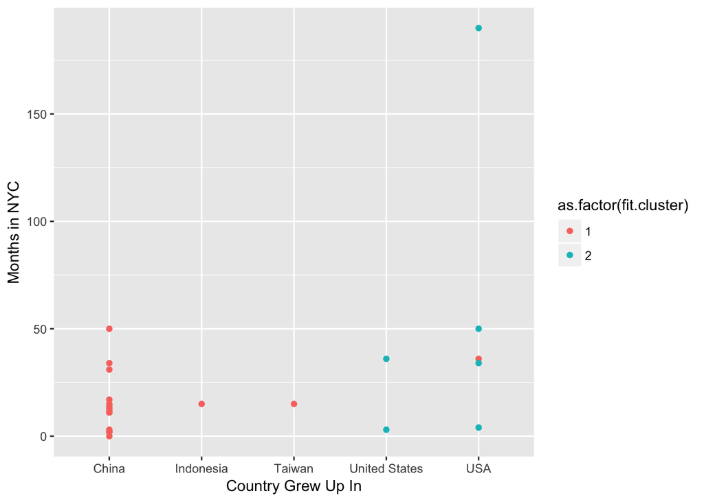

```r
ggplot(df_cluster, aes(country.grew, live.nyc, colour=as.factor(fit.cluster))) + geom_point() + xlab("Country Grew Up In") + ylab("Months in NYC")
```

## Scatterplot Matrix

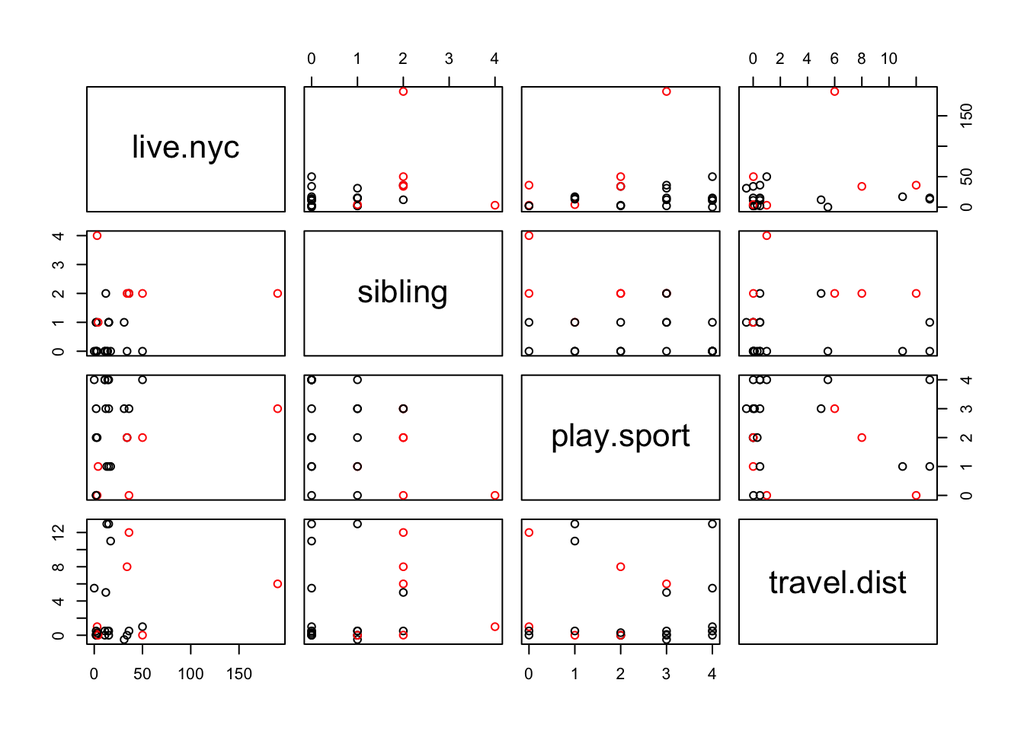

```r
# Basic Scatterplot Matrix
pairs(df_cluster[,3:6], col=df_cluster$fit.cluster)
```

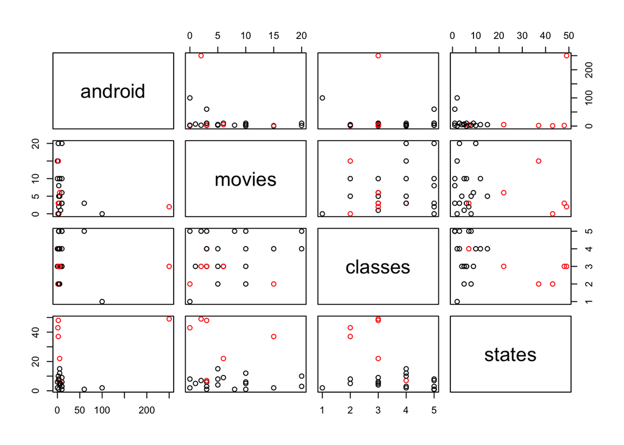

```r
pairs(df_cluster[,7:10], col=df_cluster$fit.cluster)
```

## 5. Analyze

```r
count(df_cluster, fit.cluster)
```

```
## # A tibble: 2 x 2
##   fit.cluster     n
##         <int> <int>
## 1           1    19
## 2           2     6
```

### Determine number of clusters using elbow plot

We should consider using the elbow plot to determine optimal number of clusters to use. The elbow plot looks at the total within-clusters sum of squares that results from adding a cluster to the kmeans k, or clustering size.

```r
# Compute and plot wss for k = 2 to k = 15.
k.max <- 15
wss <- sapply(1:k.max,
              function(k){kmeans(df_s, k, nstart=50,iter.max = 15 )$tot.withinss})
wss
```

```
##  [1] 192.00000 150.76478 125.14715 101.91207  82.22217  65.14815  54.40744
##  [8]  45.78548  38.97584  32.79804  27.60846  22.98482  18.22424  15.30593
## [15]  12.60350
```

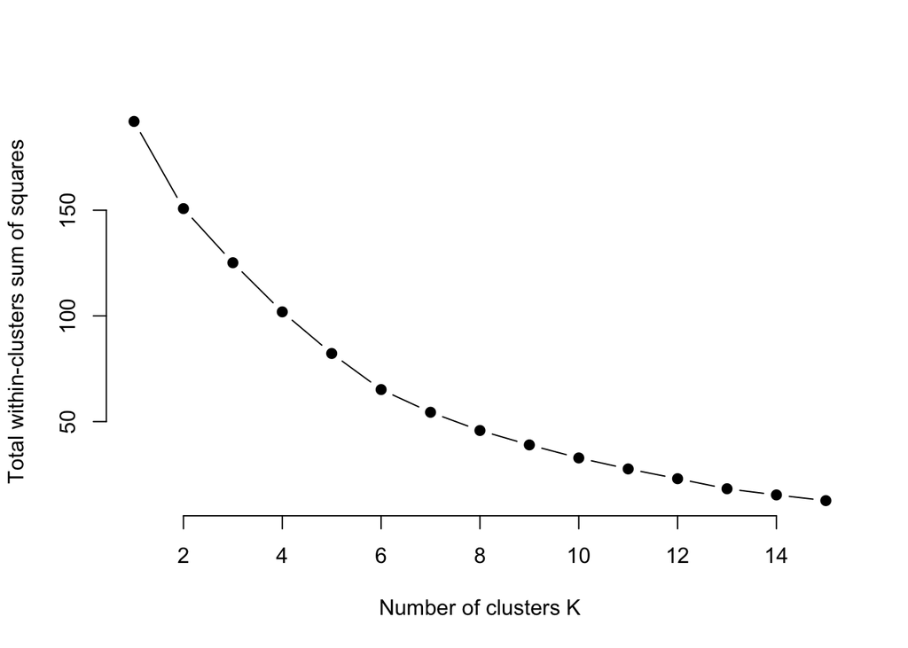

```r
plot(1:k.max, wss,
     type="b", pch = 19, frame = FALSE,
     xlab="Number of clusters K",
     ylab="Total within-clusters sum of squares")
```

The elbow plot shows optimal number of clusters K is around 6 or 7 for this dataset. However since the n size is low, the recommendation then might be to revisit the scaled variables the kmeans is running on and rerun the elbow plot.